# Outlier Detection - Entrega 2 - Nuevas tendencias en minerías de datos

Maria Lucia Guastoni

8/4/2021

# 1. Introducción

En el presente trabajo se analizará el dataset “Vertebral Column” con el objetivo de detectar outliers o valores atípicos.

# 2. Carga y análisis de los datos

En primer lugar se cargan los datos:

```r
data1 <- read.csv("column_2C.dat", sep = " ", header = F, stringsAsFactors = T)
colnames(data1) <- c("pelvic_incidence", "pelvic_tilt", "lumbar_lordosis_angle", "sacral_slope", "pelvic_radius", "grade_spondyl", "label")
data <- data1[, c(1:6)]
```

El set de datos a analizar contiene información referente a seis características biomecánicas derivadas de la forma y orientación de la pelvis y la columna lumbar de 310 pacientes, a saber:

1. incidencia pélvica
2. inclinación pélvica
3. ángulo de lordosis lumbar
4. inclinación sacra
5. radio pélvico
6. grado de espondilolistesis

También contiene una variable, la que se busca predecir, y consta de dos clases. Por un lado, los pacientes que poseen hernia discal o espondilolistesis, han sido clasificados como “anómalos” (abnormal). Por el otro lado, los pacientes clasificados como “normal”. La proporción de cada una de las clases es:

```r
table(data1$label)
```

```
 AB  NO
210 100
```

```r
round(prop.table(table(data1$label)), 3)
```

```
   AB    NO
0.677 0.323
```

En cuanto a las variables explicativas, a continuación se presenta un resúmen de cada una de ellas:

```r
summary(data1)
```

```
 pelvic_incidence  pelvic_tilt    lumbar_lordosis_angle  sacral_slope
 Min.   : 26.15   Min.   :-6.55   Min.   : 14.00        Min.   : 13.37
 1st Qu.: 46.43   1st Qu.:10.67   1st Qu.: 37.00        1st Qu.: 33.35
 Median : 58.69   Median :16.36   Median : 49.56        Median : 42.41
 Mean   : 60.50   Mean   :17.54   Mean   : 51.93        Mean   : 42.95
 3rd Qu.: 72.88   3rd Qu.:22.12   3rd Qu.: 63.00        3rd Qu.: 52.69
 Max.   :129.83   Max.   :49.43   Max.   :125.74        Max.   :121.43
 pelvic_radius    grade_spondyl    label
 Min.   : 70.08   Min.   :-11.06   AB:210
 1st Qu.:110.71   1st Qu.:  1.60   NO:100
 Median :118.27   Median : 11.77
 Mean   :117.92   Mean   : 26.30
 3rd Qu.:125.47   3rd Qu.: 41.28
 Max.   :163.07   Max.   :418.54
```

Se chequea que no existan valores faltantes:

```r
colSums(is.na(data))
```

```
     pelvic_incidence           pelvic_tilt lumbar_lordosis_angle
                    0                     0                     0
         sacral_slope         pelvic_radius         grade_spondyl
                    0                     0                     0
```

Como puede observarse, no existen valores faltantes.

A continuación se analizan los datos de manera gráfica, a través de un scatterplot que muestra la variable target en relación a las features :

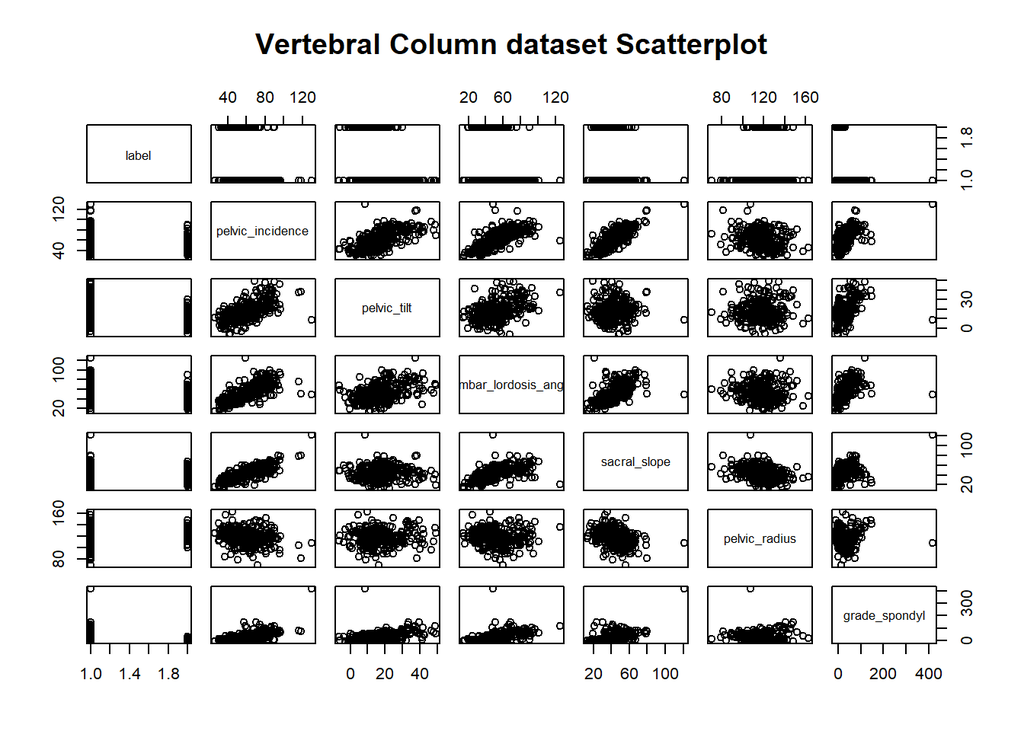

```r
pairs(~label+., data=data1,
      main="Vertebral Column dataset Scatterplot")
```

En el gráfico pueden observarse algunos valores aislados de la nube de puntos, que muy probablemente sean outliers. Para saberlo, en el próximo apartado, se realizarán diferentes análisis.

# 3. Detección de outliers

En este apartado se aplicarán diversas medidas estadísticas y algortimos de detección de outliers. En primer lugar, se llevará a cabo una reducción de la dimensionalidad mediante Principal Components Analysis (PCA), con el fin de poder visualizar los resultados que se obtengan.

## 3.1 PCA

Para comenzar, es necesario estandarizamos los datos y luego calcular distance matrix, que mide la distancia euclídea entre cada par de observaciones:

```r
data_sc <- scale(data)
distance_matrix <- as.matrix(dist(data_sc))
```

Y a continuación se aplica PCA:

```r
data.pca <- prcomp(data_sc)
summary(data.pca)
```

```
Importance of components:
                         PC1    PC2    PC3     PC4     PC5       PC6
Standard deviation     1.802 1.0930 0.8724 0.68741 0.57097 0.0002224
Proportion of Variance 0.541 0.1991 0.1268 0.07875 0.05434 0.0000000
Cumulative Proportion  0.541 0.7401 0.8669 0.94566 1.00000 1.0000000
```

A los efectos de poder realizar gráficos en dos dimensiones, se seleccionan los dos primeros componentes, que conjuntamente explican el 74% de la variación total.

En función de estos dos componentes, se grafica cada una de las observaciones del dataset:

```r
plotting <- data.table(data.pca$x[, 1:2])
plotting[, Observacion := seq(1,nrow(data))]
```

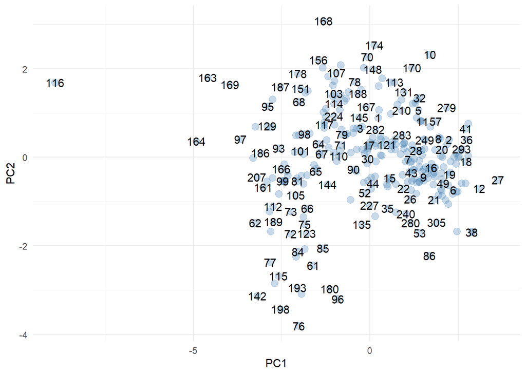

```r
g1 <- ggplot(plotting, aes(x = PC1, y = PC2)) +
    geom_point(size = 3, colour = "steelblue", alpha = 0.3) +
    geom_text(aes(label = Observacion), check_overlap = TRUE) +
    theme_minimal()
g1
```

De la representación de los datos a través de los dos principales componentes se observa que existen algunos valores alejados de la nube de puntos.

```r
pca_labels <- data.table(data.pca$x[, 1:2])
pca_labels[, Observacion := seq(1,nrow(data))]
pca_labels[, Label := data1$label]
```

## 3.2 Distancia Mahalanobis

En primer lugar se evalúa la distancia de Mahalanobis, que mide el número de desviaciones estándar de cada punto P a la media de la distribución D. Es una generalización multidimensional de la idea de medir a cuántas desviaciones estándar se aleja P de la media de D.

```r
mahalanobis <- mahalanobis(data_sc, colMeans(data), cov(data))
```

Se utilizará el paquete MVN para detectar multivalued outliers:

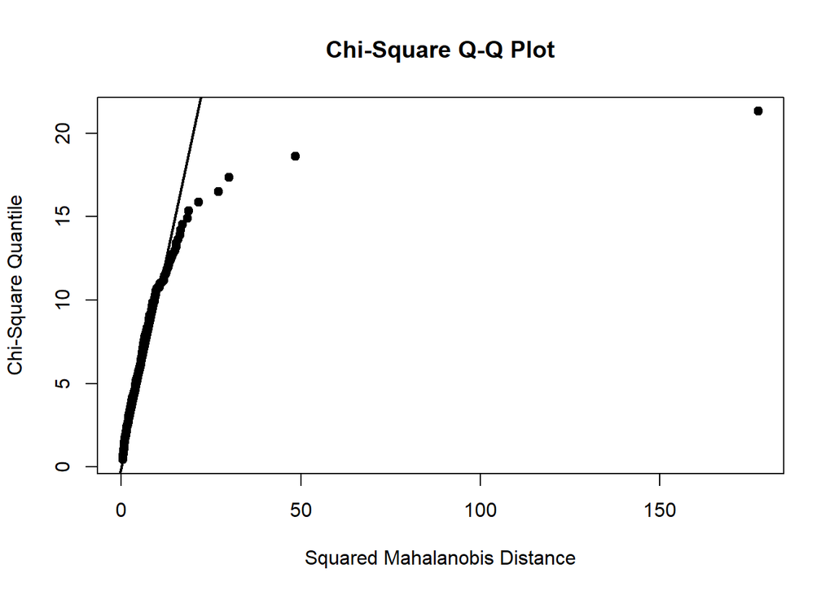

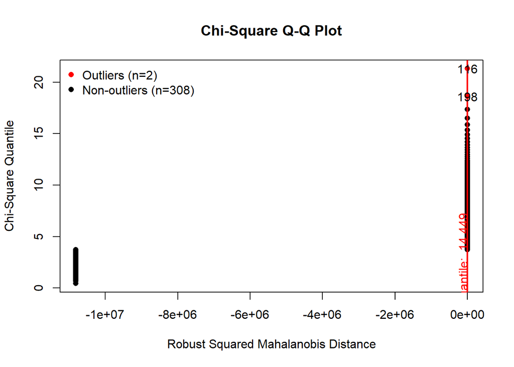

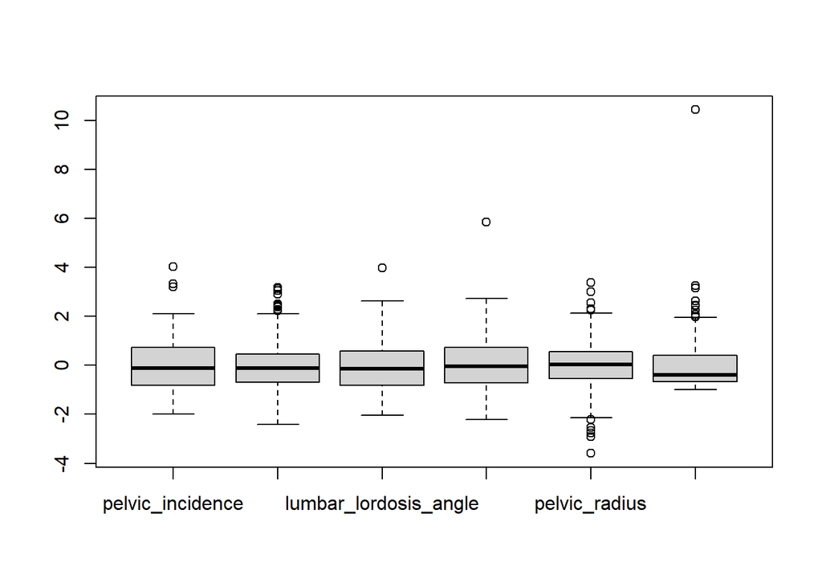

```r
results1 <- MVN::mvn(data = data, mvnTest = "hz",
               univariateTest = "AD", univariatePlot = "box",
               multivariatePlot = "qq", multivariateOutlierMethod = "quan",
               showOutliers = TRUE)
```

```r
mahalanobis_out <- data.table(Observacion = rownames(results1$multivariateOutliers),
                      MahalanobisOutlier = results1$multivariateOutliers$Outlier)
mahalanobis_out
```

```
   Observacion MahalanobisOutlier
1:         116               TRUE
2:         198               TRUE
```

Con este método, se han detectado dos observaciones que son outliers: la 116 y la 198.

También existe otro método:

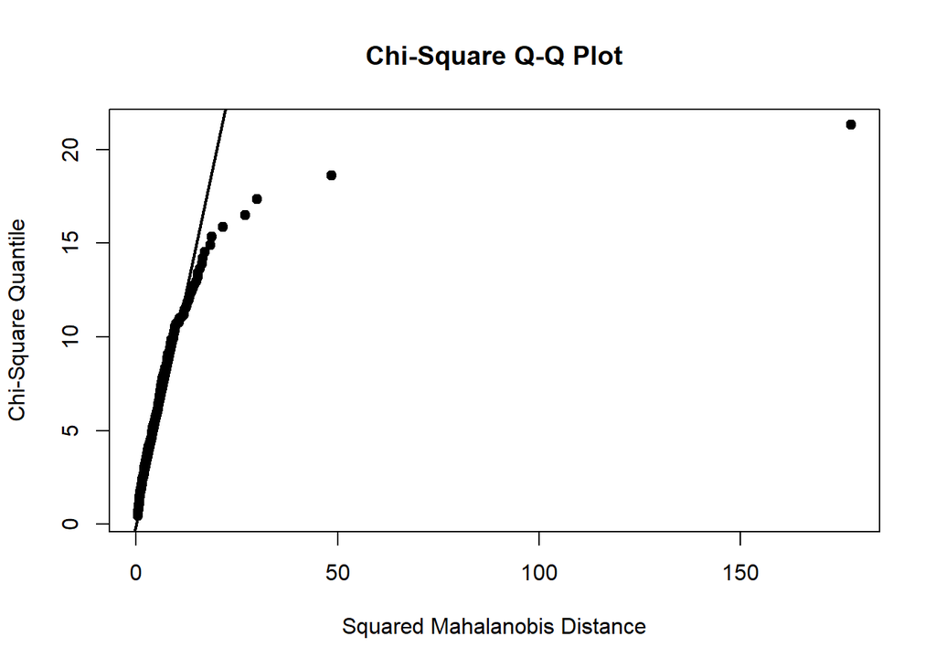

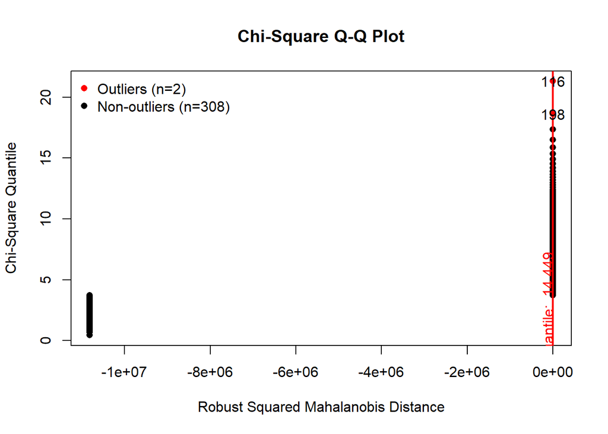

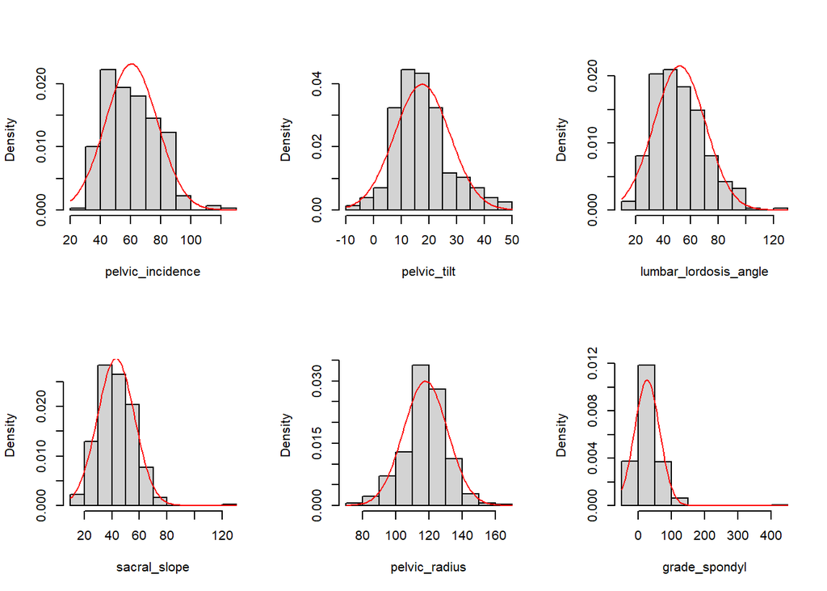

```r
results2 <- MVN::mvn(data = data, mvnTest = "hz",
               univariateTest = "AD", univariatePlot = "histogram",
               multivariatePlot = "qq", multivariateOutlierMethod = "quan",
               showOutliers = TRUE)
```

```r
myoutliers2 <- data.table(Observacion = rownames(results2$multivariateOutliers),
                      MahalanobisOutlier = results2$multivariateOutliers$Outlier)
myoutliers2$Observacion <- as.integer(myoutliers2$Observacion)
myoutliers2
```

```
   Observacion MahalanobisOutlier
1:         116               TRUE
2:         198               TRUE
```

```r
myoutliers2 <- merge(plotting, myoutliers2, by = "Observacion")
myoutliers2
```

```
   Observacion       PC1       PC2 MahalanobisOutlier
1:         116 -8.914411  1.683786               TRUE
2:         198 -2.533480 -3.428664               TRUE
```

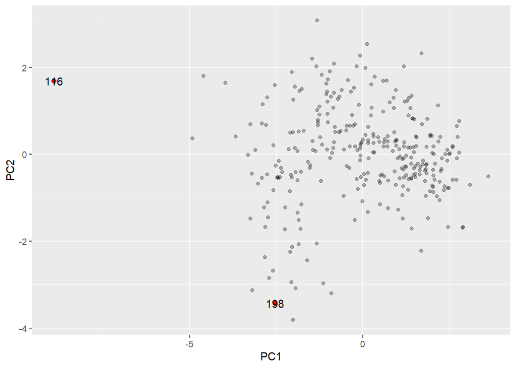

```r
ggplot(plotting, aes(x = PC1, y = PC2)) +
  geom_point(alpha=0.3) +
  geom_point(data=myoutliers2,
             aes(x = PC1, y = PC2),
             color='red',
             size=2,
             label = myoutliers2$Observacion)+
    geom_text(data = myoutliers2, aes(label = Observacion), check_overlap = TRUE)
```

```r
data[c(96, 116, 163, 198),]
```

```
    pelvic_incidence pelvic_tilt lumbar_lordosis_angle sacral_slope
96             57.52       33.65                 50.91        23.88
116           129.83        8.40                 48.38       121.43
163           118.14       38.45                 50.84        79.70
198            58.83       37.58                125.74        21.25
    pelvic_radius grade_spondyl
96         140.98        148.75
116        107.69        418.54
163         81.02         74.04
198        135.63        117.31
```

```r
lapply(data, median)
```

```
$pelvic_incidence
[1] 58.69

$pelvic_tilt
[1] 16.36

$lumbar_lordosis_angle
[1] 49.565

$sacral_slope
[1] 42.405

$pelvic_radius
[1] 118.265

$grade_spondyl
[1] 11.765
```

## 3.3 `DBSCAN`

En esta sección se aplica `DBSCAN`, un algoritmo de clustering de Machine Learning que se basa en la densidad de los puntos para encontrar outliers. Existen dos hipertparámetros que es necesario definir:

- eps: el radio en el cual se buscarán vecinos
- minPts: el número mínimo de observaciones que debe contener el área definida por el radio (eps) para que un punto sea considerado central y no outlier.

El algoritmo arroja como resultado los clústers que encuentra en base a los datos y a los parámetros definidos, así como los outliers.

Para poder evalúar la performance del algoritmo, se generará una matriz de confusión. Sin embargo, es necesario hacer un ajuste a los resultados que arroja `DBSCAN` para poder construir dicha matriz: dado que `DBSCAN` puede generar más de un clúster, y las labels de los datos son solo dos (AB y NO), se tomarán como uno solo los diversos clústers que genere el algortimo, para poder tener de esta manera sólo dos clases y así comparar con las dos clases que conforman la etiqueta de los datos.

A continuación se convierte a númerica la label de los datos:

```r
data1$label <- ifelse(data1$label == "AB",0,1)
data1$label <- as.factor(data1$label)
```

Con ayuda del paquete `caret`, se evalúan 5.800 diversas combinaciones de los dos parámetros de `DBSCAN`, para luego seleccionar aquella que arroje un mejor resultado. Para ello, se genera el siguiente grid:

```r
eps <- c(seq(0.1,20, by=0.1))
minPts <- c(seq(2,30, by=1))
parms <- expand.grid(eps = eps, minPts = minPts)
```

A continuación se define la función que evaluará todas las combinaciones de parámetros definidas previamente:

```r
accuracy_dbscan <- function(datos){
  accuracy1 <- NULL; parms$accuracy <- NULL
  for(i in 1:NROW(parms)){
       datos_dbscan <- dbscan(scale(datos), eps = parms$eps[i], minPts = parms$minPts[i])
      datos_dbscan_cl <- datos_dbscan$cluster
      datos_dbscan_transformed <- ifelse(datos_dbscan_cl == 0,0,1)
      accuracy1 <- confusionMatrix(as.factor(datos_dbscan_transformed), data1$label, positive = "0")
      parms$accuracy[i] <- accuracy1$overall[1]
  }
  parms
}
```

Finalmente, se evalúa la función con el grid antes definido y se identifica el mejor resultado obtenido :

```r
resultados_dbscan <- accuracy_dbscan(data)
which.max(resultados_dbscan$accuracy)
```

```
[1] 2008
```

```r
resultados_dbscan[which.max(resultados_dbscan$accuracy),]
```

```
     eps minPts  accuracy
2008 0.8     12 0.7548387
```

Se observa que el mejor resultado se alcanza con un `eps` de 0.8 y `minPts` de 12, que logra un accuracy de 0.75. A continuación se evalúa el modelo con los mejores parámetros:

```r
mejor_dbscan <- dbscan(scale(data), eps = 0.8, minPts = 12)
mejor_dbscan
```

```
DBSCAN clustering for 310 objects.
Parameters: eps = 0.8, minPts = 12
The clustering contains 1 cluster(s) and 208 noise points.

  0   1
208 102

Available fields: cluster, eps, minPts
```

```r
cm_dbscan <- confusionMatrix(as.factor(mejor_dbscan$cluster), data1$label, positive = "0")
```

Se observa que el algoritmo predice 208 outliers y 102 observaciones que corresponden a un mismo clúster. A pesar de que estos valores se encuentran muy cerca de la cantidad de casos normales y anómalos reales (100 y 210 respectivamente), puede verse en la diagonal secundaria de la matriz de confusión que ha clasficado observaciones que en realidad eran anómalas como normales y viceversa, motivo por el cual el accuracy es del 75% (falsos positivos + falsos negativos = 76 observaciones = 25%).

Se visualiza estos resultados graficamente:

```r
plotting[, DClusters := mejor_dbscan$cluster]
plotting
```

```
            PC1         PC2 Observacion DClusters
  1:  0.2379766  0.89202234           1         0
  2:  2.2428268  0.40066183           2         1
  3: -0.2778477  0.65282624           3         0
  4: -0.3736769  0.65683696           4         0
  5:  1.3713793  1.05994584           5         1
 ---
306:  1.5387154  0.18734067         306         1
307:  1.2481122 -0.03210101         307         1
308:  0.4967789 -0.66419665         308         0
309:  1.5287477  0.40651352         309         1
310:  2.4435831  0.09740961         310         1
```

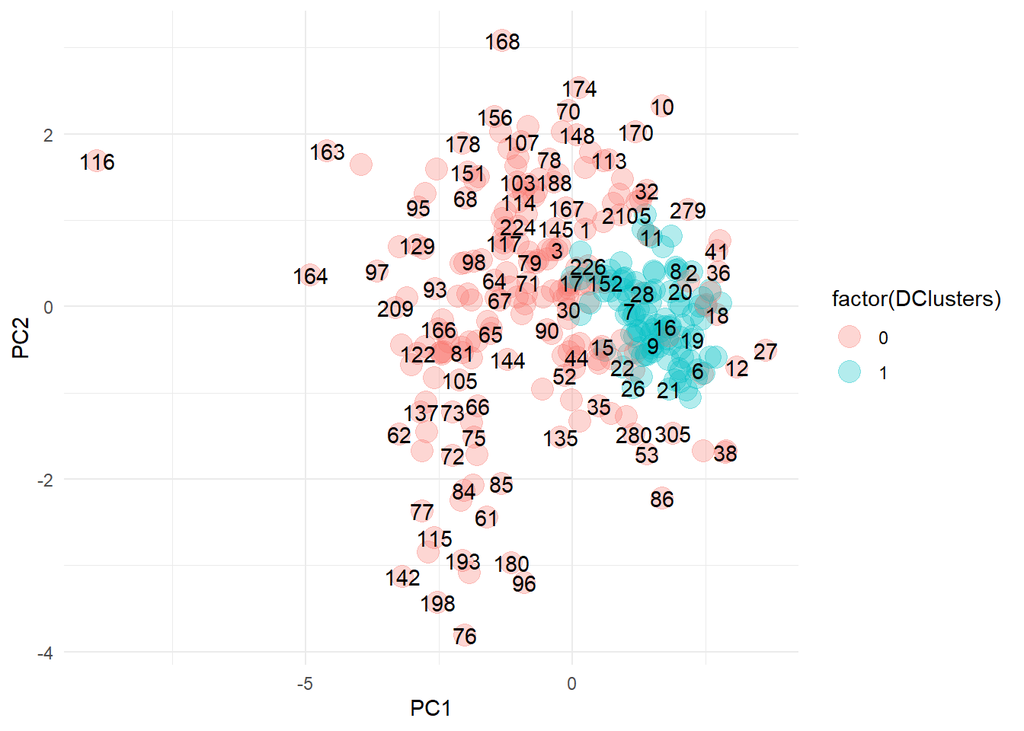

```r
ggplot(plotting, aes(x = PC1, y = PC2)) +
  geom_point(aes(colour = factor(DClusters)), size = 5, alpha = 0.3) +
  geom_text(aes(label = Observacion), check_overlap = TRUE) +
  theme_minimal()
```

Del gráfico se observa que los puntos detectados como normales se encuentran entre 0 y 2.5 de PC1 y entre -1 y 1 de PC2. Por su parte, los anómalos están distribuidos más ampliamente a lo largo del dominio de PC2 así como de PC1.

## 3.4 Expectation Maximization

El siguiente algoritmo que se evaluará en los datos es `Expectation Maximization`. Es un algoritmo no supervisado de clustering, y tiene en cuenta la varianza y la orientación de los objetos para encontrar “subespacios similares”.

El único parámetro que debe definirse es `G`, el número de clústers. Dado que se desea agrupar los datos en anómalos y normales, se fijará este parámetro en 2:

```r
expm <- Mclust(scale(data), G = 2)
summary(expm)
```

```
----------------------------------------------------
Gaussian finite mixture model fitted by EM algorithm
----------------------------------------------------

Mclust VVE (ellipsoidal, equal orientation) model with 2 components:

 log-likelihood   n df      BIC      ICL
       309.8877 310 40 390.3124 371.6247

Clustering table:
  1   2
161 149
```

Se observa que el algoritmo clasifica como anómalas 161 observaciones, y como normales 149.

Al igual que en el caso anterior, se calculará la matriz de confusión:

```r
plotting[, ExpMax := expm$classification]
plotting$ExpMax <- ifelse(plotting$ExpMax == 1,0,1)
cm_expmax <- confusionMatrix(as.factor(plotting$ExpMax), data1$label, positive = "0")
cm_expmax
```

```
Confusion Matrix and Statistics

          Reference
Prediction   0   1
         0 151  10
         1  59  90

               Accuracy : 0.7774
                 95% CI : (0.727, 0.8225)
    No Information Rate : 0.6774
    P-Value [Acc > NIR] : 6.680e-05

                  Kappa : 0.5486

 Mcnemar's Test P-Value : 7.536e-09

            Sensitivity : 0.7190
            Specificity : 0.9000
         Pos Pred Value : 0.9379
         Neg Pred Value : 0.6040
             Prevalence : 0.6774
         Detection Rate : 0.4871
   Detection Prevalence : 0.5194
      Balanced Accuracy : 0.8095

       'Positive' Class : 0
```

En este caso, el accuracy es superior: 77.74%, versus 75.48% de `DBSCAN`. Se han clasificado correctamente 241 observaciones, de las cuales 151 corresponden a la clase anómala, y 90 a la normal, mientras que 69 han sido erróneamente clasificadas (10 falsos anómalos y 59 falsos normales).

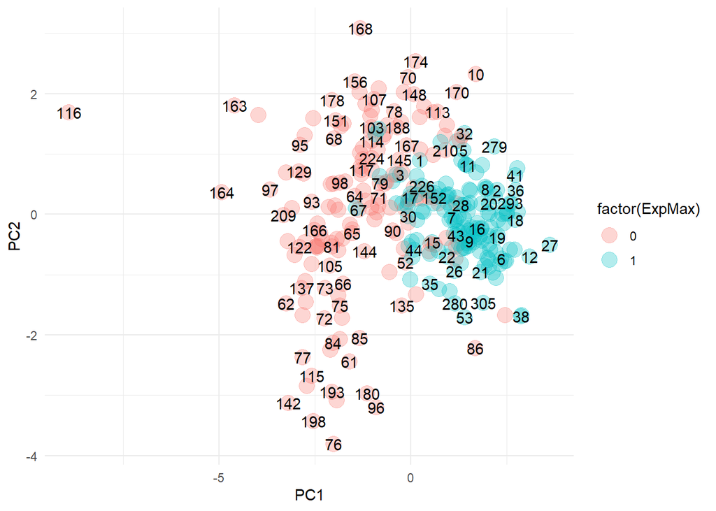

```r
ggplot(plotting, aes(x = PC1, y = PC2)) +
  geom_point(aes(colour = factor(ExpMax)), size = 5, alpha = 0.3) +
  geom_text(aes(label = Observacion), check_overlap = TRUE) +
  theme_minimal()
```

Comparando con la clasficación realizada por DBSCAN, Expectation Maximization clasifica como normales algunos puntos menores a 0 en relación a PC1 que en DBSCAN son clasificados como anómalos.

## 3.5 Local Outlier Factor

Local Outlier Factor (LOF) es un algoritmo que identifica outliers en función de la densidad de los puntos. La densidad local de un punto es comparada con la de sus vecinos: si la densidad local es significativamente menor que la de los vecinos, y por tanto se tiene un valor LOF superior a la unidad, se podría estar en presencia de un outlier.

A continuación se calcula el score LOF, considerando valores de k (cantidad de vecinos más cercanos) = 2,4,6,8,10,12,14 y 16.

```r
obs.scores.lof <- lof(data, k=seq(2,16,2))
head(obs.scores.lof)
```

```
             2         4         6         8        10        12       14
[1,] 1.2579572 1.3436129 1.3058042 1.2780615 1.2951590 1.3226806 1.327293
[2,] 1.1339581 1.0506392 1.0174336 1.0206331 1.0181625 1.0377952 1.035804
[3,] 1.1750947 0.9981617 0.9709535 0.9989076 1.0271778 1.0586246 1.068190
[4,] 1.2651013 1.2337771 1.1774118 1.1782901 1.1714003 1.1780447 1.141790
[5,] 1.1146093 1.2563742 1.2599247 1.2281021 1.2122388 1.2169584 1.193874
[6,] 0.9790748 1.0103677 0.9866999 0.9968922 0.9996617 0.9981129 1.015908
           16
[1,] 1.317312
[2,] 1.021867
[3,] 1.070145
[4,] 1.128973
[5,] 1.194181
[6,] 1.015936
```

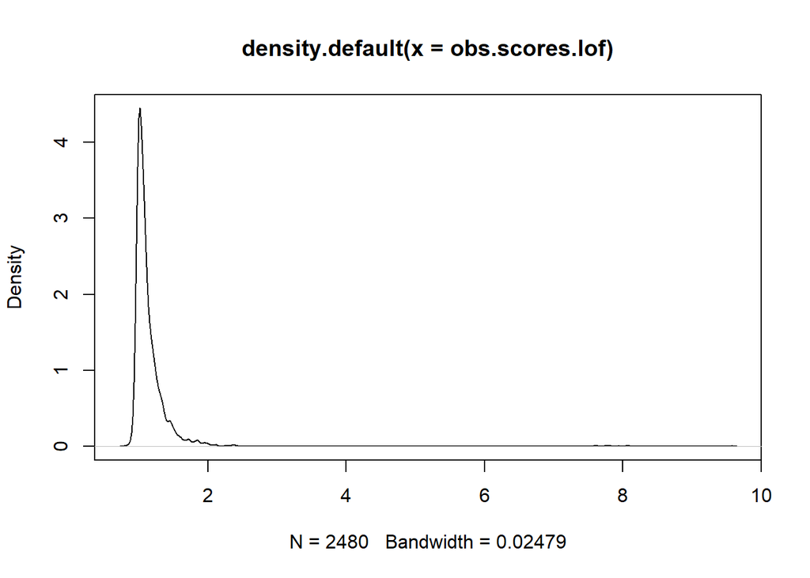

```r
plot(density(obs.scores.lof))
```

El gráfico muestra la densidad de las observaciones del dataset. Puede verse que la mayoría está alrededor de 1, llegando hasta 2.

Lo próximo es calcular la matriz de confusión para cada uno de los k valores, con el objetivo de indetificar cuál de ellos arroja un mejor resultado.

### k = 2

```r
obs.scores.lof2 <- as.data.frame(obs.scores.lof[,1])
colnames(obs.scores.lof2) <- "k_2"
obs.scores.lof2 <- ifelse(obs.scores.lof2$k_2 > 1, 0,1)
plotting[, LOF2 := obs.scores.lof2]
cm_LOF2 <- confusionMatrix(as.factor(plotting$LOF2), data1$label, positive = "0")
cm_LOF2
```

```
Confusion Matrix and Statistics

          Reference
Prediction   0   1
         0 168  74
         1  42  26

               Accuracy : 0.6258
                 95% CI : (0.5693, 0.6799)
    No Information Rate : 0.6774
    P-Value [Acc > NIR] : 0.976451

                  Kappa : 0.0655

 Mcnemar's Test P-Value : 0.003999

            Sensitivity : 0.8000
            Specificity : 0.2600
         Pos Pred Value : 0.6942
         Neg Pred Value : 0.3824
             Prevalence : 0.6774
         Detection Rate : 0.5419
   Detection Prevalence : 0.7806
      Balanced Accuracy : 0.5300

       'Positive' Class : 0
```

### k = 4

```r
obs.scores.lof4 <- as.data.frame(obs.scores.lof[,2])
colnames(obs.scores.lof4) <- "k_4"
obs.scores.lof4 <- ifelse(obs.scores.lof4$k_4 > 1, 0,1)
plotting[, LOF4 := obs.scores.lof4]
cm_LOF4 <- confusionMatrix(as.factor(plotting$LOF4), data1$label, positive = "0")
cm_LOF4
```

```
Confusion Matrix and Statistics

          Reference
Prediction   0   1
         0 176  79
         1  34  21

               Accuracy : 0.6355
                 95% CI : (0.5792, 0.6892)
    No Information Rate : 0.6774
    P-Value [Acc > NIR] : 0.9484

                  Kappa : 0.0545

 Mcnemar's Test P-Value : 3.486e-05

            Sensitivity : 0.8381
            Specificity : 0.2100
         Pos Pred Value : 0.6902
         Neg Pred Value : 0.3818
             Prevalence : 0.6774
         Detection Rate : 0.5677
   Detection Prevalence : 0.8226
      Balanced Accuracy : 0.5240

       'Positive' Class : 0
```

### k = 6

```r
obs.scores.lof6 <- as.data.frame(obs.scores.lof[,3])
colnames(obs.scores.lof6) <- "k_6"
obs.scores.lof6 <- ifelse(obs.scores.lof6$k_6 > 1, 0,1)
plotting[, LOF6 := obs.scores.lof6]
cm_LOF6 <- confusionMatrix(as.factor(plotting$LOF6), data1$label, positive = "0")
cm_LOF6
```

```
Confusion Matrix and Statistics

          Reference
Prediction   0   1
         0 174  79
         1  36  21

               Accuracy : 0.629
                 95% CI : (0.5726, 0.683)
    No Information Rate : 0.6774
    P-Value [Acc > NIR] : 0.969

                  Kappa : 0.0435

 Mcnemar's Test P-Value : 8.984e-05

            Sensitivity : 0.8286
            Specificity : 0.2100
         Pos Pred Value : 0.6877
         Neg Pred Value : 0.3684
             Prevalence : 0.6774
         Detection Rate : 0.5613
   Detection Prevalence : 0.8161
      Balanced Accuracy : 0.5193

       'Positive' Class : 0
```

### k = 8

```r
obs.scores.lof8 <- as.data.frame(obs.scores.lof[,4])
colnames(obs.scores.lof8) <- "k_8"
obs.scores.lof8 <- ifelse(obs.scores.lof8$k_8 > 1, 0,1)
plotting[, LOF8 := obs.scores.lof8]
cm_LOF8 <- confusionMatrix(as.factor(plotting$LOF8), data1$label, positive = "0")
cm_LOF8
```

```
Confusion Matrix and Statistics

          Reference
Prediction   0   1
         0 170  84
         1  40  16

               Accuracy : 0.6
                 95% CI : (0.5431, 0.655)
    No Information Rate : 0.6774
    P-Value [Acc > NIR] : 0.9982988

                  Kappa : -0.0344

 Mcnemar's Test P-Value : 0.0001127

            Sensitivity : 0.8095
            Specificity : 0.1600
         Pos Pred Value : 0.6693
         Neg Pred Value : 0.2857
             Prevalence : 0.6774
         Detection Rate : 0.5484
   Detection Prevalence : 0.8194
      Balanced Accuracy : 0.4848

       'Positive' Class : 0
```

### k = 10

```r
obs.scores.lof10 <- as.data.frame(obs.scores.lof[,5])
colnames(obs.scores.lof10) <- "k_10"
obs.scores.lof10 <- ifelse(obs.scores.lof10$k_10 > 1, 0,1)
plotting[, LOF10 := obs.scores.lof10]
cm_LOF10 <- confusionMatrix(as.factor(plotting$LOF10), data1$label, positive = "0")
cm_LOF10
```

```
Confusion Matrix and Statistics

          Reference
Prediction   0   1
         0 167  83
         1  43  17

               Accuracy : 0.5935
                 95% CI : (0.5366, 0.6487)
    No Information Rate : 0.6774
    P-Value [Acc > NIR] : 0.999220

                  Kappa : -0.0388

 Mcnemar's Test P-Value : 0.000512

            Sensitivity : 0.7952
            Specificity : 0.1700
         Pos Pred Value : 0.6680
         Neg Pred Value : 0.2833
             Prevalence : 0.6774
         Detection Rate : 0.5387
   Detection Prevalence : 0.8065
      Balanced Accuracy : 0.4826

       'Positive' Class : 0
```

### k = 12

```r
obs.scores.lof12 <- as.data.frame(obs.scores.lof[,6])
colnames(obs.scores.lof12) <- "k_12"
obs.scores.lof12 <- ifelse(obs.scores.lof12$k_12 > 1, 0,1)
plotting[, LOF12 := obs.scores.lof12]
cm_LOF12 <- confusionMatrix(as.factor(plotting$LOF12), data1$label, positive = "0")
cm_LOF12
```

```
Confusion Matrix and Statistics

          Reference
Prediction   0   1
         0 158  76
         1  52  24

               Accuracy : 0.5871
                 95% CI : (0.5301, 0.6425)
    No Information Rate : 0.6774
    P-Value [Acc > NIR] : 0.99966

                  Kappa : -0.0081

 Mcnemar's Test P-Value : 0.04206

            Sensitivity : 0.7524
            Specificity : 0.2400
         Pos Pred Value : 0.6752
         Neg Pred Value : 0.3158
             Prevalence : 0.6774
         Detection Rate : 0.5097
   Detection Prevalence : 0.7548
      Balanced Accuracy : 0.4962

       'Positive' Class : 0
```

### k = 14

```r
obs.scores.lof14 <- as.data.frame(obs.scores.lof[,7])
colnames(obs.scores.lof14) <- "k_14"
obs.scores.lof14 <- ifelse(obs.scores.lof14$k_14 > 1, 0,1)
plotting[, LOF14 := obs.scores.lof14]
cm_LOF14 <- confusionMatrix(as.factor(plotting$LOF14), data1$label, positive = "0")
cm_LOF14
```

```
Confusion Matrix and Statistics

          Reference
Prediction   0   1
         0 159  77
         1  51  23

               Accuracy : 0.5871
                 95% CI : (0.5301, 0.6425)
    No Information Rate : 0.6774
    P-Value [Acc > NIR] : 0.99966

                  Kappa : -0.0138

 Mcnemar's Test P-Value : 0.02713

            Sensitivity : 0.7571
            Specificity : 0.2300
         Pos Pred Value : 0.6737
         Neg Pred Value : 0.3108
             Prevalence : 0.6774
         Detection Rate : 0.5129
   Detection Prevalence : 0.7613
      Balanced Accuracy : 0.4936

       'Positive' Class : 0
```

### k = 16

```r
obs.scores.lof16 <- as.data.frame(obs.scores.lof[,8])
colnames(obs.scores.lof16) <- "k_16"
obs.scores.lof16 <- ifelse(obs.scores.lof16$k_16 > 1, 0,1)
plotting[, LOF16 := obs.scores.lof16]
cm_LOF16 <- confusionMatrix(as.factor(plotting$LOF16), data1$label, positive = "0")
cm_LOF16
```

```
Confusion Matrix and Statistics

          Reference
Prediction   0   1
         0 159  77
         1  51  23

               Accuracy : 0.5871
                 95% CI : (0.5301, 0.6425)
    No Information Rate : 0.6774
    P-Value [Acc > NIR] : 0.99966

                  Kappa : -0.0138

 Mcnemar's Test P-Value : 0.02713

            Sensitivity : 0.7571
            Specificity : 0.2300
         Pos Pred Value : 0.6737
         Neg Pred Value : 0.3108
             Prevalence : 0.6774
         Detection Rate : 0.5129
   Detection Prevalence : 0.7613
      Balanced Accuracy : 0.4936

       'Positive' Class : 0
```

### Comparación de LOF con diferentes valores de k

Ahora se comparan los resultados obtenidos para seleccionar el mejor:

```
[1] "k_2 = Accuracy: 0.626"
```

```
[1] "k_4 = Accuracy: 0.635"
```

```
[1] "k_6 = Accuracy: 0.629"
```

```
[1] "k_8 = Accuracy: 0.6"
```

```
[1] "k_10 = Accuracy: 0.594"
```

```
[1] "k_12 = Accuracy: 0.587"
```

```
[1] "k_14 = Accuracy: 0.587"
```

```
[1] "k_16 = Accuracy: 0.587"
```

Puede verse que el mejor accuracy es alcanzado con un valor de k = 4.

Veamos graficamente los resultados:

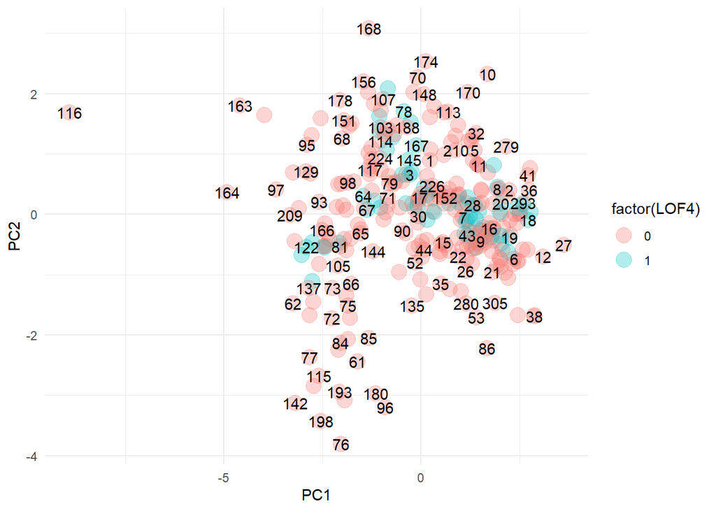

```r
ggplot(plotting, aes(x = PC1, y = PC2)) +
  geom_point(aes(colour = factor(LOF4)), size = 5, alpha = 0.3) +
  geom_text(aes(label = Observacion), check_overlap = TRUE) +
  theme_minimal()
```

Se observa que las observaciones “normales” se encuetran menos concentradas que en las clasificaciones de DBSCAN y Expectation Maximization.

# 4. Comparación final de modelos

En el presente apartado se comparan los 3 modelos analizados: DBSCAN, Expectation Maximization y LOF. La matriz de confusión de cada uno de los modelos es:

DBSCAN:

```r
cm_dbscan
```

```
Confusion Matrix and Statistics

          Reference
Prediction   0   1
         0 171  37
         1  39  63

               Accuracy : 0.7548
                 95% CI : (0.703, 0.8017)
    No Information Rate : 0.6774
    P-Value [Acc > NIR] : 0.001772

                  Kappa : 0.442

 Mcnemar's Test P-Value : 0.908677

            Sensitivity : 0.8143
            Specificity : 0.6300
         Pos Pred Value : 0.8221
         Neg Pred Value : 0.6176
             Prevalence : 0.6774
         Detection Rate : 0.5516
   Detection Prevalence : 0.6710
      Balanced Accuracy : 0.7221

       'Positive' Class : 0
```

Expectation Maximization:

```r
cm_expmax
```

```
Confusion Matrix and Statistics

          Reference
Prediction   0   1
         0 151  10
         1  59  90

               Accuracy : 0.7774
                 95% CI : (0.727, 0.8225)
    No Information Rate : 0.6774
    P-Value [Acc > NIR] : 6.680e-05

                  Kappa : 0.5486

 Mcnemar's Test P-Value : 7.536e-09

            Sensitivity : 0.7190
            Specificity : 0.9000
         Pos Pred Value : 0.9379
         Neg Pred Value : 0.6040
             Prevalence : 0.6774
         Detection Rate : 0.4871
   Detection Prevalence : 0.5194
      Balanced Accuracy : 0.8095

       'Positive' Class : 0
```

Local Outlier Factor:

```r
cm_LOF4
```

```
Confusion Matrix and Statistics

          Reference
Prediction   0   1
         0 176  79
         1  34  21

               Accuracy : 0.6355
                 95% CI : (0.5792, 0.6892)
    No Information Rate : 0.6774
    P-Value [Acc > NIR] : 0.9484

                  Kappa : 0.0545

 Mcnemar's Test P-Value : 3.486e-05

            Sensitivity : 0.8381
            Specificity : 0.2100
         Pos Pred Value : 0.6902
         Neg Pred Value : 0.3818
             Prevalence : 0.6774
         Detection Rate : 0.5677
   Detection Prevalence : 0.8226
      Balanced Accuracy : 0.5240

       'Positive' Class : 0
```

Comparando el ajuste de los tres modelos, se observa que el que mejores resultados arroja en términos de accracy es Expectation Maximization, seguido de cerca por DBSCAN, y en tercer lugar LOF.

Sin embargo, si lo que interesa es identificar datos anómalos, en este caso los la clase positiva, debe analizarse también la “Sensitivity”, que mide cuán acertadamente ha clasificado el algoritmo los verdaderos positivos, en relación a estos y a los falsos negativos. En este sentido, el mejor algoritmo es LOF, con k = 4, con un valor de sensitivity de 0.8381, mientras que Expactation Maximization alcanza el valor más bajo de los tres algoritmos.

Gráficamente:

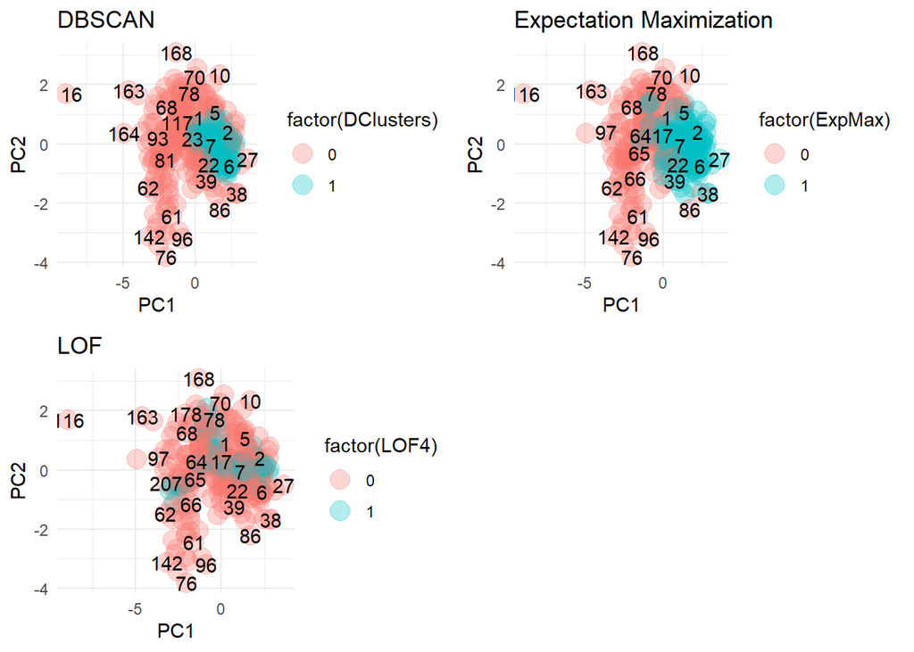

```r
g1 <- ggplot(plotting, aes(x = PC1, y = PC2)) +
  geom_point(aes(colour = factor(DClusters)), size = 5, alpha = 0.3) +
  geom_text(aes(label = Observacion), check_overlap = TRUE) +
  labs(title = "DBSCAN") +
  theme_minimal()

g2 <- ggplot(plotting, aes(x = PC1, y = PC2)) +
  geom_point(aes(colour = factor(ExpMax)), size = 5, alpha = 0.3) +
  geom_text(aes(label = Observacion), check_overlap = TRUE) +
  labs(title = "Expectation Maximization", size = 4) +
  theme_minimal()

g3 <- ggplot(plotting, aes(x = PC1, y = PC2)) +
  geom_point(aes(colour = factor(LOF4)), size = 5, alpha = 0.3) +
  geom_text(aes(label = Observacion), check_overlap = TRUE) +
  labs(title = "LOF") +
  theme_minimal()

plot_grid(g1,g2,g3)
```

Puede verse que DBSCAN y Expectation Maximization realizan una clasificación similar, encontrándose las observaciones normales más concentradas con respecto al otro algoritmo.

Comparando gráficamente con las labels originales:

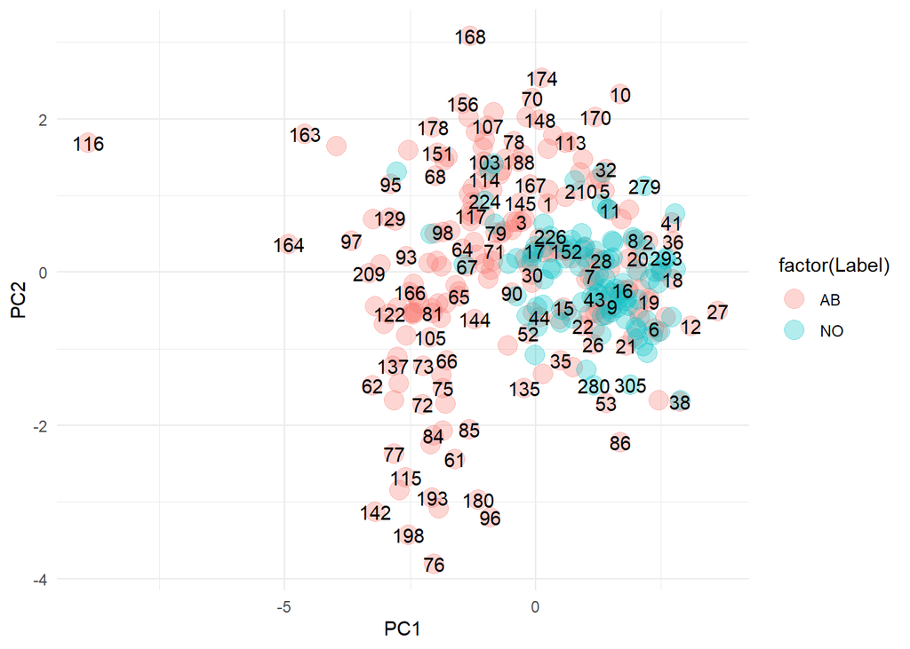

```r
ggplot(pca_labels, aes(x = PC1, y = PC2)) +
  geom_point(aes(colour = factor(Label)), size = 5, alpha = 0.3) +
  geom_text(aes(label = Observacion), check_overlap = TRUE) +
  theme_minimal()
```

Se ve que, gráficamente, el algoritmo de Expectation Maximization logra captar mejor la distribución de los puntos originales, mientras que LOF no capta la concetración de los puntos normales.

Para finalizar, podría decirse que se selecciona el algoritmo Expectation Maximization entre los tres evaluados, dado que es el que tiene mejor accuracy y el que mejor capta la distribución de las dos clases.